# Introduction to LOESS Regression

**Locally Estimated Scatterplot Smoothing (LOESS)**: a non-parametric regression method. It is useful when the relationship between the predictor and the response variable is complex and cannot be well-modeled by traditional linear or polynomial regression.

## Difference between B-spline and LOESS regression.

- B-splines: We fit a non-linear model using ordinary (or weighted) least squares to the entire dataset. This is called a *global* regression model
  - We still need to assume the data are normally distributed (with common variance if we do not use weighting)
- LOESS: We are fitting a weighted polynomial model within a neighborhood **only** around a certain point $(x_i,y_i)$. This is called a *local* regression model.

## Procedure for LOESS regression

**Smoothing Parameter (Span)** ($\alpha < 1$): The parameter that controls the degree of smoothing to fit a localized regression model for $(x_i,y_i)$

- Only $\alpha$ proportion of the points will have any weight for which we fit our localized regression model, and these are the closest values in distance to $x_i$

**Weights** ($w_{ij}$): The weight associated data point $(x_j,y_j)$ for fitting a localized regression model for data point $(x_i,y_i)$.

- let $d = \max |x_j - x_i|$ which is the largest distance between $x_i$ and the $\alpha$ proportion of points used in our LOESS regression
- We typically use a tricube weight function to calculate the weights:
  $$w_{ij} = \max\left(\left(1 - \left(\frac{|x_j - x_i|}{d}\right)^3\right)^3,0\right)$$

Let’s see what this weight function looks like around $x = 0$

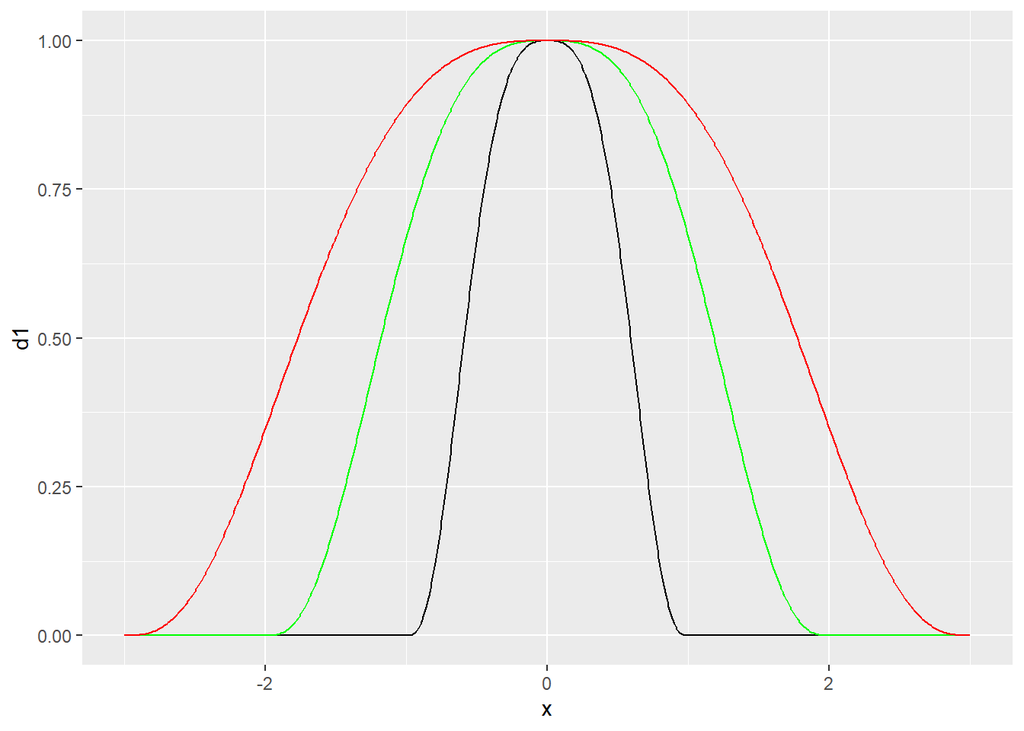

```r
library(tidyverse)
x <- seq(-3,3,0.01)

d1 <- pmax((1 - (abs(x)/1)^3)^3,0)
d2 <- pmax((1 - (abs(x)/2)^3)^3,0)
d3 <- pmax((1 - (abs(x)/3)^3)^3,0)
ggplot() +
  geom_line(aes(x=x,y=d1)) +
  geom_line(aes(x=x,y=d2),colour="green") +
  geom_line(aes(x=x,y=d3),colour="red")
```

**Local Regression**: After weighting is performed, localized regression for $(x_i,y_i)$ is fit using by minimizing the following sums of squares

$$\sum_{j = 1}^n w_{ij}(y_j - \sum_{k=0}^p\beta_k x_j^k)^2$$
where $p$ is the largest polynomial to be used to fit the regression. In R, the default is 2.

- After performing a least squares regression analysis on this subset of data, we can obtain
  $$\hat{y}_i = \hat{\beta}_0$$
  .
- After obtaining $\{\hat{y}_i:i = 1,\cdots,n\}$, interpolation is conducted using, wait for it, **splines**!
- Standard errors of $\hat{y}_i$ can be obtained using R, with the formula too complicated to discuss in this class.